# 第14回・第15回課題

> オブジェクト指向プログラミングおよび演習1 第14回・第15回

> GUIアプリを作ってみよう(イベントの設定方法や他のコンポーネントを操作する方法を知っておこう)

それぞれの動作サンプルをmoodleにて配布しています。 あくまで動作の確認を行うためのサンプルです。デザインをきっちりとサンプルと揃える必要はありません。

実行を行う場合は、`java -jar jarファイル名`のコマンドを使ってください。

# 課題1

## クリックカウンターの作成

クリックした回数を表示するプログラムを作成します。

### 課題内容

プロジェクト名は「ClickCounter」としてください。

1. 以下のGUIフォームデザインを参考に、クリック数を表示するカウンタ表示ラベル、加算ボタン、リセットボタン、減算ボタンを配置します。細かい設定値は各自自由です。

[figure not shown]

   - ラベル、ボタン等の各要素は、適切なフィールド名を付けてください。（加算ボタンなら"bIncrement"など）
2. カウンタ表示ラベルはテキスト（text）の初期表示を"0"とします。
3. 加算ボタンを押下したときは、カウンタ表示ラベルの数値を1ずつ足します。
4. リセットボタンを押下したときは、カウンタ表示ラベルの数値を"0"に戻します。
5. 減算ボタンを押下したときは、カウンタ表示ラベルの数値を1ずつ減らします。

### 課題の提出について

1. 提出するファイルは、以下2つを提出してください。
   - 実行可能形式の**jarファイル : ClickCounter.jar**
   - プロジェクトディレクトリを圧縮したもの（ClickCounter.zip）

# 課題2

## ランダムに決定した5桁の整数値を当てる数当てゲーム

5桁の数字がランダムに決定され、5桁の数値を入力することで「それより大きい」「それより小さい」「正解」の表示を行い、「正解」の場合、正解の数値をリセットすることができるプログラムを作成します。

### 課題内容

プロジェクト名は「NumberQuiz」としてください。

1. 以下のGUIフォームデザインを参考に、テキストフィールド、ボタン、メッセージ表示用のラベル等、各コントロールを配置します。細かい設定値は各自自由です。

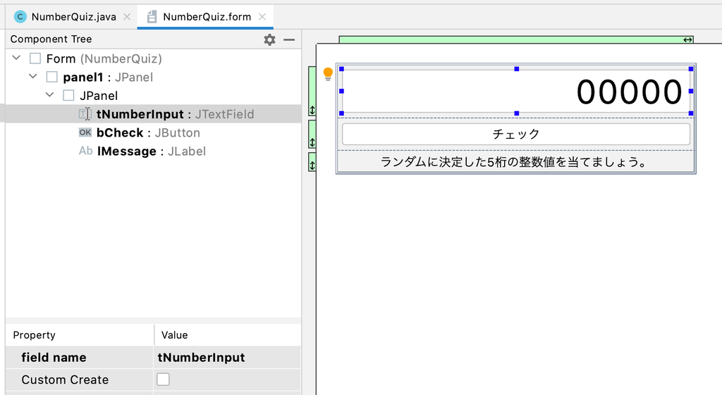

2. 初期化処理にて、内部で保持される値が0〜99999の範囲でランダムに決定する
3. 画面のテキストフィールドには数値のみを入力する想定だが、数値以外入力不可の設定等は不要（できたらやっても良い）
4. チェックのボタンを押下した際、ランダムに決定した数値と入力された数値を比較し、メッセージ（詳細は以下）を表示する
   - 入力された数値がランダムに決定した数値より10000以上離れて小さければ、「それよりもっともっと大きい」旨を表示
   - 入力された数値がランダムに決定した数値より10000未満かつ1000以上離れて小さければ、「それよりもっと大きい」旨を表示
   - 入力された数値がランダムに決定した数値より1000未満で小さければ、「それより大きい」旨を表示
   - 入力された数値がランダムに決定した数値より1000未満で大きければ、「それより小さい」旨を表示
   - 入力された数値がランダムに決定した数値より10000未満かつ1000以上離れて大きれば、「それよりもっと小さい」旨を表示
   - 入力された数値がランダムに決定した数値より10000以上離れて大きければ、「それよりもっともっと小さい」旨を表示
   - 同じ値であれば、「正解」を表示
   - これらのメッセージの末尾には、チェックを行った回数を表示させる（「（試行回数:n回）)」のように）
5. 正解した場合は、チェックボタンのテキストを「チェック」から「リセット」に変える
6. チェックボタンから「リセット」ボタンに変更されたボタンは、押下で初期化処理にて初期化を行う
7. テキストフィールドに数値として変換できない文字が入力されるなどの例外的状況は、各自の判断で例外処理を実装する
   - メッセージ表示用に用意する最下部のラベル等を使用してエラーの表示を行っても良い

### 課題の提出について

1. 提出するファイルは、以下2つを提出してください。
   - 実行可能形式の**jarファイル : NumberQuiz.jar**
   - プロジェクトディレクトリを圧縮したもの（NumberQuiz.zip）

# 課題3

## ライツアウトっぽいゲーム

詳しくは、以下のWikipediaの記事をご参照ください。

- [ライツアウト - Wikipedia](https://ja.wikipedia.org/wiki/%E3%83%A9%E3%82%A4%E3%83%84%E3%82%A2%E3%82%A6%E3%83%88)

### 課題内容

プロジェクト名は、「LightsOut」とします。

1. 以下のGUIフォームデザインを参考に、9つの「ラベル」を配置する
   - 細かい設定値は各自自由とするが、ボタンで代替するのはダメです。

[figure not shown]

2. 各ラベルの初期表示は、0か、1かでランダムとする
   - ランダムな0,1を生成する場合は、`String r = String.valueOf(new java.util.Random().nextInt(2))` を使うと良いでしょう。
3. それぞれのラベルをクリックすると、クリックしたラベル自体とグリッド上の上下左右にあるラベルの0,1が反転する
   - 左上のラベルをクリックした場合は、左上、左中、中上のラベルが数値反転する。上下左右にラベルがある場合のみ反転すればよいです。
   - ラベルをクリックした時のイベントは、actionPerformedではないので、調べて実装してください。
4. ラベルをクリック後反転した結果、すべてのラベルが1になったらゲームクリアとする
   - ゲームクリアのダイアログメッセージ（`showMessageDialog`を使用する※下記参照）を表示し、再度ランダムで配置する。

### 補足情報

#### ダイアログメッセージを出す方法

ダイアログメッセージの出し方についてですが、javax.swing.JOptionPaneクラスにあるstaticメソッドの、`showMessageDialog`を使用します。

以下のステートメントでメッセージボックスが出せます。メッセージボックスを出したい箇所に貼り付けてください。

```java
javax.swing.JOptionPane.showMessageDialog(
        panel1,                                         // コンテンツを配置しているペインコントロール
        "GameClear!!",                                  // メッセージ
        "3x3 LightsOut",                                // タイトル
        javax.swing.JOptionPane.INFORMATION_MESSAGE);   // ダイアログタイプ(ここは他にもエラーや警告表示などがある)
```

## 課題の提出について

1. 提出するファイルは、以下2つを提出してください。
   - 実行可能形式の**jarファイル : LightsOut.jar**
   - プロジェクトディレクトリを圧縮したもの（LightsOut.zip）

# 課題4

## URLを指定してHTMLを取得、保存可能なエディタ

Javaには、`java.net.http.HttpClient`にてHTTPでの接続を行えるライブラリが存在します。

これを使って、GUI上の入力されたURLに対してHTTPのリクエストを発行し、受け取ったレスポンスの本文をテキストエリアに設定し、保存ボタンによりテキストを保存できるアプリケーションを作ります。

※`java.net.http.HttpClient`の使い方および、これを使ったHTTPリクエストの投げ方、レスポンスの受け取り方は各自でしらべて実装すること。

### 課題内容

プロジェクト名は、「HtmlGetter」とします。

1. 以下のGUIフォームデザインを参考に作成する
   - 細かい設定値は各自自由とする

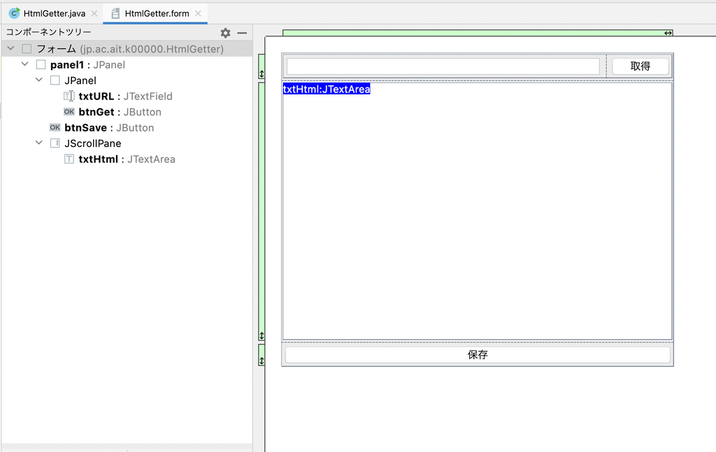

2. URL入力欄の初期値は、「`http://`」とする
   - テキストを全選択した状態で起動時にフォーカスを当てられるとなお良いです。
3. 実際にWebサイトが存在するURLを入力後「取得」ボタンを押下すると、指定されたURLに対してHTTPまたはHTTPSでのリクエストを行う
4. リクエストに対して、レスポンスを受け取ったら、そのレスポンスの本文をテキストエリアに表示する
5. 保存ボタンを押下したら、ファイルの保存ダイアログを出し、指定されたファイル名でテキストエリアの文字列を保存する

## 課題の提出について

1. 提出するファイルは、以下2つを提出してください。
   - 実行可能形式の**jarファイル : HtmlGetter.jar**
   - プロジェクトディレクトリを圧縮したもの（HtmlGetter.zip）

# 課題5

## 名前と電話番号をJSON形式で保存できるアドレス帳

JSON形式のファイルの取り扱いには、標準ライブラリよりも、外部ライブラリが便利に扱えることがあります。

この課題では、単純なテキストのみで構成される名前と電話番号の組み合わせのデータを複数個追加でき、追加したデータをJSON形式のテキストとして保存できるアプリケーションを作成します。

### 課題内容

プロジェクト名は、「AddressBook」とします。

1. 以下のGUIフォームデザインを参考に作成する
   - 細かい設定値は各自自由とするが、登録データの表示を行うコンポーネントはJListを必ず使用すること

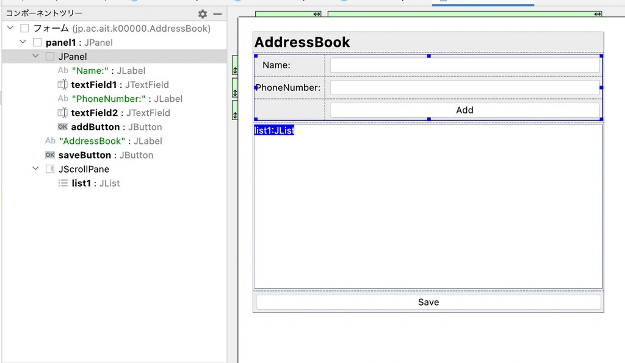

2. name,phoneNumberを入力して、「Add」ボタンを押すと、JListで配置されたリストに「name:phoneNumber」の形式で1件データが追加される
3. 「Save」ボタンを押下すると、ファイルの保存ダイアログを出し、指定されたファイル名で JListに追加されたデータリストをJSON形式のテキストデータで保存する
   - このときの形式は、以下のJSONフォーマットにしたがってください。

### 保存されるJSONのフォーマット

以下2件のデータを登録したとする。

#### 1. 愛工太郎:000-0000-0000

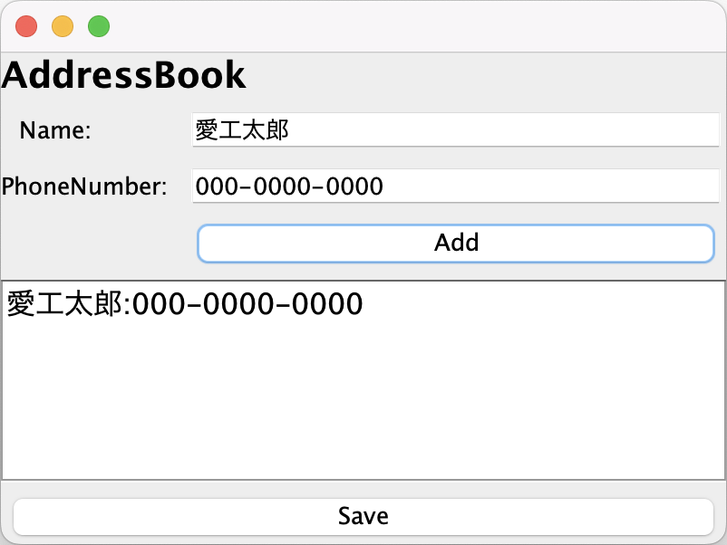

#### 2. 愛工次郎:111-1111-1111

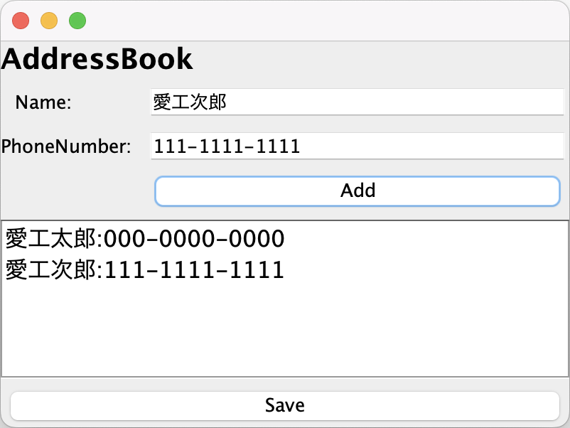

#### 出力フォーマット

```json
[{"name":"愛工太郎","phoneNumber":"000-0000-0000"},{"name":"愛工次郎","phoneNumber":"111-1111-1111"}]
```

## 課題の提出について

1. 提出するファイルは、以下2つを提出してください。
   - 実行可能形式の**jarファイル : AddressBook.jar**
   - プロジェクトディレクトリを圧縮したもの（AddressBook.zip）